# Practical Machine Learning - Course Project

Author Liliia Smilyk

## Synopsis

In this project, we use data from accelerometers on the belt, forearm, arm and dumbell of 6 participants to predict the manner in which they did the exercise (the “classe” variable in training data set). We will use random forest method to build predictive model.

## Loading packages

```r
library(dplyr)
library(caret)
library(randomForest)
library(knitr)
```

## Loading data

```r
fileURL_train <- "https://d396qusza40orc.cloudfront.net/predmachlearn/pml-training.csv"
a <- download.file(fileURL_train, destfile = "pml-training.csv", method = "curl")
df_train <- read.csv("pml-training.csv", header = TRUE, row.names = 1)

fileURL_test <- "https://d396qusza40orc.cloudfront.net/predmachlearn/pml-testing.csv"
b <- download.file(fileURL_test, destfile = "pml-testing.csv", method = "curl")
df_test <- read.csv("pml-testing.csv", header = TRUE, row.names = 1)
```

Now we have two data frames - df_train (data for building predictive model) and df_test.

## Cleaning and exploring data

Let`s look at our training data.

```r
str(df_train)
```

```
## 'data.frame':    19622 obs. of  159 variables:
##  $ user_name               : Factor w/ 6 levels "adelmo","carlitos",..: 2 2 2 2 2 2 2 2 2 2 ...
##  $ raw_timestamp_part_1    : int  1323084231 1323084231 1323084231 1323084232 1323084232 1323084232 1323084232 1323084232 1323084232 1323084232 ...
##  $ raw_timestamp_part_2    : int  788290 808298 820366 120339 196328 304277 368296 440390 484323 484434 ...
##  $ cvtd_timestamp          : Factor w/ 20 levels "02/12/2011 13:32",..: 9 9 9 9 9 9 9 9 9 9 ...
##  $ new_window              : Factor w/ 2 levels "no","yes": 1 1 1 1 1 1 1 1 1 1 ...
##  $ num_window              : int  11 11 11 12 12 12 12 12 12 12 ...
##  $ roll_belt               : num  1.41 1.41 1.42 1.48 1.48 1.45 1.42 1.42 1.43 1.45 ...
##  $ pitch_belt              : num  8.07 8.07 8.07 8.05 8.07 8.06 8.09 8.13 8.16 8.17 ...
##  $ yaw_belt                : num  -94.4 -94.4 -94.4 -94.4 -94.4 -94.4 -94.4 -94.4 -94.4 -94.4 ...
##  $ total_accel_belt        : int  3 3 3 3 3 3 3 3 3 3 ...
##  $ kurtosis_roll_belt      : Factor w/ 397 levels "","-0.016850",..: 1 1 1 1 1 1 1 1 1 1 ...
##  $ kurtosis_picth_belt     : Factor w/ 317 levels "","-0.021887",..: 1 1 1 1 1 1 1 1 1 1 ...
##  $ kurtosis_yaw_belt       : Factor w/ 2 levels "","#DIV/0!": 1 1 1 1 1 1 1 1 1 1 ...
##  $ skewness_roll_belt      : Factor w/ 395 levels "","-0.003095",..: 1 1 1 1 1 1 1 1 1 1 ...
```

[output cut: 86 more lines]

As we can see there are lots of variables that we don`t need. So we remove calculated and sequence variables from training and testing data sets.

```r
names_minus <- c(grep("^.*timestamp.*", names(df_train)),
                 grep("^min.*", names(df_train)),
                 grep("^max.*", names(df_train)),
                 grep("^var.*", names(df_train)),
                 grep("stddev.*", names(df_train)),
                 grep("^avg.*", names(df_train)),
                 grep("^total.*", names(df_train)),
                 grep("^new_window.*", names(df_train)),
                 grep("^num_window.*", names(df_train)))
df_train1 <- select(df_train, -names_minus)
```

[output not shown]

```r
df_test1 <- select(df_test, -names_minus)
```

Also we need to remove variables that contains missing values.

```r
df_train2 <- df_train1[, colSums(is.na(df_train1)) == 0]
df_test2 <- df_test1[, colSums(is.na(df_test1)) == 0]
```

And we need to remove variables with near zero variance.

```r
nzv <- nearZeroVar(df_train2)
df_train2 <- df_train2[, -nzv]
nzv_test <- nearZeroVar(df_test2)
nzv_test
```

```
## integer(0)
```

As we can see there are no such variables in testing data.

```r
dim(df_train2)
```

```
## [1] 19622    50
```

```r
dim(df_test2)
```

```
## [1] 20 50
```

Now we have clean data to build predictive model and use it.

## Building predictive model

At first we use cross validation to split our training data set (df_train2) into two subsets - training (60%) and validation (40%) data sets. We use random subsampling method.

```r
set.seed(1614)
InTrain <- createDataPartition(y = df_train2$classe, p = 0.6, list = FALSE)
training <- df_train2[InTrain,]
validation <- df_train2[-InTrain,]
```

Determine the model using randomForest package.

```r
fit <- randomForest(classe ~ ., data = training)
```

Use model to predict classe for validation data set.

```r
pred <- predict(fit, validation)
con_matrix <- confusionMatrix(pred, validation$classe)
print(con_matrix)
```

```
## Confusion Matrix and Statistics
##
##           Reference
## Prediction    A    B    C    D    E
##          A 2230   11    0    0    0
##          B    1 1498   10    0    0
##          C    0    9 1356   12    0
##          D    1    0    2 1274    5
##          E    0    0    0    0 1437
##
## Overall Statistics
##
##                Accuracy : 0.9935
##                  95% CI : (0.9915, 0.9952)
##     No Information Rate : 0.2845
##     P-Value [Acc > NIR] : < 2.2e-16
##
##                   Kappa : 0.9918
##
##  Mcnemar's Test P-Value : NA
##
## Statistics by Class:
##
##                      Class: A Class: B Class: C Class: D Class: E
## Sensitivity            0.9991   0.9868   0.9912   0.9907   0.9965
## Specificity            0.9980   0.9983   0.9968   0.9988   1.0000
## Pos Pred Value         0.9951   0.9927   0.9847   0.9938   1.0000
## Neg Pred Value         0.9996   0.9968   0.9981   0.9982   0.9992
## Prevalence             0.2845   0.1935   0.1744   0.1639   0.1838
## Detection Rate         0.2842   0.1909   0.1728   0.1624   0.1832
## Detection Prevalence   0.2856   0.1923   0.1755   0.1634   0.1832
## Balanced Accuracy      0.9986   0.9925   0.9940   0.9947   0.9983
```

```r
paste("Accuracy of predictive model is high - ", round(con_matrix$overall['Accuracy'], 4), ".")
```

```
## [1] "Accuracy of predictive model is high -  0.9935 ."
```

Out of sample error is less than 0.01. So model is pretty good.  
Let`s plot the model.

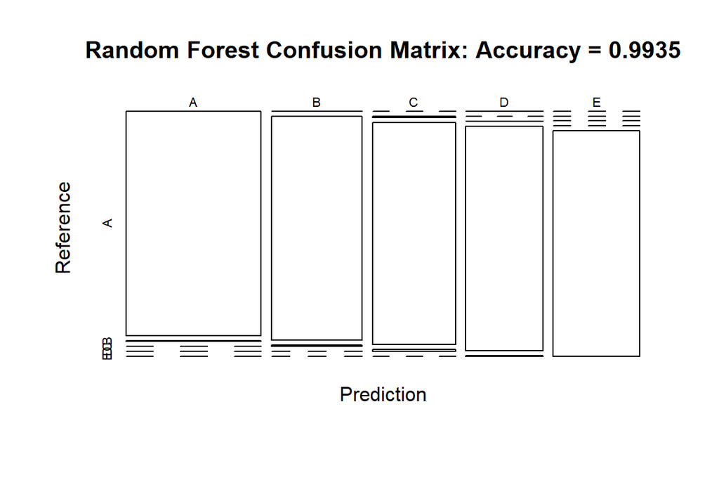

```r
plot(con_matrix$table, col = con_matrix$byClass,
     main = paste("Random Forest Confusion Matrix: Accuracy =",
                  round(con_matrix$overall['Accuracy'], 4)))
```

## Applying predictive model to testing data set

```r
pred_test <- predict(fit, df_test2)
df_test2$classe_prediction <- pred_test
```

The result of prediction will be used to answer Course Project Prediction Quiz.